# Risk Factor Analysis

## Outcome Variable

**Outcome Variable:** sstunted

## Predictor Variables

**Intervention Variable:** nchldlt5

**Adjustment Set:**

- arm
- W_mage
- meducyrs
- feducyrs
- hhwealth_quart
- hfoodsec
- W_mhtcm
- W_mwtkg
- W_mbmi
- W_nrooms
- W_parity
- impfloor
- impsan
- safeh20
- delta_W_mage
- delta_meducyrs
- delta_feducyrs
- delta_hhwealth_quart
- delta_hfoodsec
- delta_W_mhtcm
- delta_W_mwtkg
- delta_W_mbmi
- delta_W_nrooms
- delta_W_parity
- delta_impfloor
- delta_impsan
- delta_safeh20

## Stratifying Variables

The analysis was stratified on these variable(s):

- agecat
- studyid
- country

## Data Summary

| agecat | studyid | country | nchldlt5 | sstunted | n_cell | n |
| --- | --- | --- | --- | --- | --- | --- |
| Birth | ki1000108-IRC | INDIA | 1 | 0 | 79 | 388 |
| Birth | ki1000108-IRC | INDIA | 1 | 1 | 5 | 388 |
| Birth | ki1000108-IRC | INDIA | 2+ | 0 | 293 | 388 |
| Birth | ki1000108-IRC | INDIA | 2+ | 1 | 11 | 388 |
| Birth | ki1017093b-PROVIDE | BANGLADESH | 1 | 0 | 388 | 539 |
| Birth | ki1017093b-PROVIDE | BANGLADESH | 1 | 1 | 3 | 539 |
| Birth | ki1017093b-PROVIDE | BANGLADESH | 2+ | 0 | 147 | 539 |
| Birth | ki1017093b-PROVIDE | BANGLADESH | 2+ | 1 | 1 | 539 |
| Birth | ki1017093c-NIH-Crypto | BANGLADESH | 1 | 0 | 515 | 732 |
| Birth | ki1017093c-NIH-Crypto | BANGLADESH | 1 | 1 | 7 | 732 |
| Birth | ki1017093c-NIH-Crypto | BANGLADESH | 2+ | 0 | 207 | 732 |
| Birth | ki1017093c-NIH-Crypto | BANGLADESH | 2+ | 1 | 3 | 732 |
| Birth | kiGH5241-JiVitA-3 | BANGLADESH | 1 | 0 | 12217 | 22431 |
| Birth | kiGH5241-JiVitA-3 | BANGLADESH | 1 | 1 | 1769 | 22431 |
| Birth | kiGH5241-JiVitA-3 | BANGLADESH | 2+ | 0 | 7766 | 22431 |
| Birth | kiGH5241-JiVitA-3 | BANGLADESH | 2+ | 1 | 679 | 22431 |
| 6 months | ki1000108-IRC | INDIA | 1 | 0 | 78 | 407 |
| 6 months | ki1000108-IRC | INDIA | 1 | 1 | 11 | 407 |
| 6 months | ki1000108-IRC | INDIA | 2+ | 0 | 300 | 407 |
| 6 months | ki1000108-IRC | INDIA | 2+ | 1 | 18 | 407 |
| 6 months | ki1017093b-PROVIDE | BANGLADESH | 1 | 0 | 428 | 604 |
| 6 months | ki1017093b-PROVIDE | BANGLADESH | 1 | 1 | 10 | 604 |
| 6 months | ki1017093b-PROVIDE | BANGLADESH | 2+ | 0 | 162 | 604 |
| 6 months | ki1017093b-PROVIDE | BANGLADESH | 2+ | 1 | 4 | 604 |
| 6 months | ki1017093c-NIH-Crypto | BANGLADESH | 1 | 0 | 492 | 715 |
| 6 months | ki1017093c-NIH-Crypto | BANGLADESH | 1 | 1 | 15 | 715 |
| 6 months | ki1017093c-NIH-Crypto | BANGLADESH | 2+ | 0 | 200 | 715 |
| 6 months | ki1017093c-NIH-Crypto | BANGLADESH | 2+ | 1 | 8 | 715 |
| 6 months | ki1066203-TanzaniaChild2 | TANZANIA, UNITED REPUBLIC OF | 1 | 0 | 1384 | 2020 |
| 6 months | ki1066203-TanzaniaChild2 | TANZANIA, UNITED REPUBLIC OF | 1 | 1 | 7 | 2020 |
| 6 months | ki1066203-TanzaniaChild2 | TANZANIA, UNITED REPUBLIC OF | 2+ | 0 | 617 | 2020 |
| 6 months | ki1066203-TanzaniaChild2 | TANZANIA, UNITED REPUBLIC OF | 2+ | 1 | 12 | 2020 |
| 6 months | ki1148112-LCNI-5 | MALAWI | 1 | 0 | 362 | 811 |
| 6 months | ki1148112-LCNI-5 | MALAWI | 1 | 1 | 28 | 811 |
| 6 months | ki1148112-LCNI-5 | MALAWI | 2+ | 0 | 384 | 811 |
| 6 months | ki1148112-LCNI-5 | MALAWI | 2+ | 1 | 37 | 811 |
| 6 months | kiGH5241-JiVitA-3 | BANGLADESH | 1 | 0 | 10177 | 16800 |
| 6 months | kiGH5241-JiVitA-3 | BANGLADESH | 1 | 1 | 710 | 16800 |
| 6 months | kiGH5241-JiVitA-3 | BANGLADESH | 2+ | 0 | 5604 | 16800 |
| 6 months | kiGH5241-JiVitA-3 | BANGLADESH | 2+ | 1 | 309 | 16800 |
| 24 months | ki1000108-IRC | INDIA | 1 | 0 | 82 | 409 |
| 24 months | ki1000108-IRC | INDIA | 1 | 1 | 7 | 409 |
| 24 months | ki1000108-IRC | INDIA | 2+ | 0 | 286 | 409 |
| 24 months | ki1000108-IRC | INDIA | 2+ | 1 | 34 | 409 |
| 24 months | ki1017093b-PROVIDE | BANGLADESH | 1 | 0 | 389 | 578 |
| 24 months | ki1017093b-PROVIDE | BANGLADESH | 1 | 1 | 35 | 578 |
| 24 months | ki1017093b-PROVIDE | BANGLADESH | 2+ | 0 | 137 | 578 |
| 24 months | ki1017093b-PROVIDE | BANGLADESH | 2+ | 1 | 17 | 578 |
| 24 months | ki1017093c-NIH-Crypto | BANGLADESH | 1 | 0 | 336 | 514 |
| 24 months | ki1017093c-NIH-Crypto | BANGLADESH | 1 | 1 | 21 | 514 |
| 24 months | ki1017093c-NIH-Crypto | BANGLADESH | 2+ | 0 | 142 | 514 |
| 24 months | ki1017093c-NIH-Crypto | BANGLADESH | 2+ | 1 | 15 | 514 |
| 24 months | ki1066203-TanzaniaChild2 | TANZANIA, UNITED REPUBLIC OF | 1 | 0 | 4 | 6 |
| 24 months | ki1066203-TanzaniaChild2 | TANZANIA, UNITED REPUBLIC OF | 1 | 1 | 1 | 6 |
| 24 months | ki1066203-TanzaniaChild2 | TANZANIA, UNITED REPUBLIC OF | 2+ | 0 | 1 | 6 |
| 24 months | ki1066203-TanzaniaChild2 | TANZANIA, UNITED REPUBLIC OF | 2+ | 1 | 0 | 6 |
| 24 months | ki1148112-LCNI-5 | MALAWI | 1 | 0 | 255 | 571 |
| 24 months | ki1148112-LCNI-5 | MALAWI | 1 | 1 | 28 | 571 |
| 24 months | ki1148112-LCNI-5 | MALAWI | 2+ | 0 | 247 | 571 |
| 24 months | ki1148112-LCNI-5 | MALAWI | 2+ | 1 | 41 | 571 |
| 24 months | kiGH5241-JiVitA-3 | BANGLADESH | 1 | 0 | 4671 | 8622 |
| 24 months | kiGH5241-JiVitA-3 | BANGLADESH | 1 | 1 | 783 | 8622 |
| 24 months | kiGH5241-JiVitA-3 | BANGLADESH | 2+ | 0 | 2607 | 8622 |
| 24 months | kiGH5241-JiVitA-3 | BANGLADESH | 2+ | 1 | 561 | 8622 |

The following strata were considered:

- agecat: 24 months, studyid: ki1000108-IRC, country: INDIA
- agecat: 24 months, studyid: ki1017093b-PROVIDE, country: BANGLADESH
- agecat: 24 months, studyid: ki1017093c-NIH-Crypto, country: BANGLADESH
- agecat: 24 months, studyid: ki1066203-TanzaniaChild2, country: TANZANIA, UNITED REPUBLIC OF
- agecat: 24 months, studyid: ki1148112-LCNI-5, country: MALAWI
- agecat: 24 months, studyid: kiGH5241-JiVitA-3, country: BANGLADESH
- agecat: 6 months, studyid: ki1000108-IRC, country: INDIA
- agecat: 6 months, studyid: ki1017093b-PROVIDE, country: BANGLADESH
- agecat: 6 months, studyid: ki1017093c-NIH-Crypto, country: BANGLADESH
- agecat: 6 months, studyid: ki1066203-TanzaniaChild2, country: TANZANIA, UNITED REPUBLIC OF
- agecat: 6 months, studyid: ki1148112-LCNI-5, country: MALAWI
- agecat: 6 months, studyid: kiGH5241-JiVitA-3, country: BANGLADESH
- agecat: Birth, studyid: ki1000108-IRC, country: INDIA
- agecat: Birth, studyid: ki1017093b-PROVIDE, country: BANGLADESH
- agecat: Birth, studyid: ki1017093c-NIH-Crypto, country: BANGLADESH
- agecat: Birth, studyid: kiGH5241-JiVitA-3, country: BANGLADESH

### Dropped Strata

Some strata were dropped due to rare outcomes:

- agecat: Birth, studyid: ki1017093b-PROVIDE, country: BANGLADESH
- agecat: Birth, studyid: ki1017093c-NIH-Crypto, country: BANGLADESH
- agecat: 6 months, studyid: ki1017093b-PROVIDE, country: BANGLADESH
- agecat: 24 months, studyid: ki1066203-TanzaniaChild2, country: TANZANIA, UNITED REPUBLIC OF

## Methods Detail

We’re interested in the causal parameters $E[Y_a]$ for all values of $a \in \mathcal{A}$. These parameters represent the mean outcome if, possibly contrary to fact, we intervened to set all units to have $A=a$. Under the randomization and positivity assumptions, these are identified by the statistical parameters $\psi_a=E_W[E_{Y|A,W}(Y|A=a,W)]$. In addition, we’re interested in the mean of $Y$, $E[Y]$ under no intervention (the observed mean). We will estimate these parameters by using SuperLearner to fit the relevant likelihood factors – $E_{Y|A,W}(Y|A=a,W)$ and $p(A=a|W)$, and then updating our likelihood fit using a joint TMLE.

For unadjusted analyses ($W=\{\}$), initial likelihoods were estimated using Lrnr_glm to estimate the simple $E(Y|A)$ and Lrnr_mean to estimate $p(A)$. For adjusted analyses, a small library containing Lrnr_glmnet, Lrnr_xgboost, and Lrnr_mean was used.

Having estimated these parameters, we will then use the delta method to estimate relative risks and attributable risks relative to a prespecified baseline level of $A$.

# Results Detail

## Results Plots

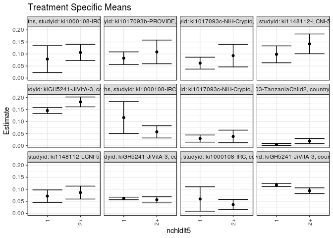

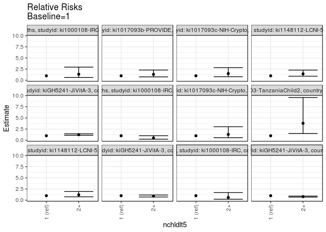

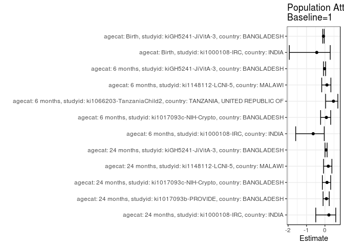

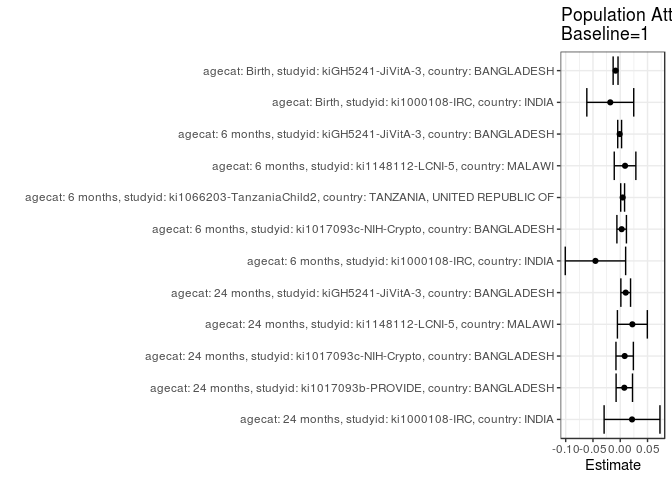

## Results Table

### Parameter: TSM

| agecat | studyid | country | intervention_level | baseline_level | estimate | ci_lower | ci_upper |
| --- | --- | --- | --- | --- | --- | --- | --- |
| Birth | ki1000108-IRC | INDIA | 1 | NA | 0.0595238 | 0.0088611 | 0.1101865 |
| Birth | ki1000108-IRC | INDIA | 2+ | NA | 0.0361842 | 0.0151644 | 0.0572040 |
| Birth | kiGH5241-JiVitA-3 | BANGLADESH | 1 | NA | 0.1177004 | 0.1108526 | 0.1245481 |
| Birth | kiGH5241-JiVitA-3 | BANGLADESH | 2+ | NA | 0.0938302 | 0.0818197 | 0.1058408 |
| 6 months | ki1000108-IRC | INDIA | 1 | NA | 0.1167068 | 0.0502972 | 0.1831163 |
| 6 months | ki1000108-IRC | INDIA | 2+ | NA | 0.0574992 | 0.0320133 | 0.0829850 |
| 6 months | ki1017093c-NIH-Crypto | BANGLADESH | 1 | NA | 0.0295858 | 0.0148264 | 0.0443452 |
| 6 months | ki1017093c-NIH-Crypto | BANGLADESH | 2+ | NA | 0.0384615 | 0.0123088 | 0.0646143 |
| 6 months | ki1066203-TanzaniaChild2 | TANZANIA, UNITED REPUBLIC OF | 1 | NA | 0.0050324 | 0.0013129 | 0.0087518 |
| 6 months | ki1066203-TanzaniaChild2 | TANZANIA, UNITED REPUBLIC OF | 2+ | NA | 0.0190779 | 0.0083846 | 0.0297712 |
| 6 months | ki1148112-LCNI-5 | MALAWI | 1 | NA | 0.0713443 | 0.0454292 | 0.0972594 |
| 6 months | ki1148112-LCNI-5 | MALAWI | 2+ | NA | 0.0861208 | 0.0592817 | 0.1129600 |
| 6 months | kiGH5241-JiVitA-3 | BANGLADESH | 1 | NA | 0.0617587 | 0.0563913 | 0.0671262 |
| 6 months | kiGH5241-JiVitA-3 | BANGLADESH | 2+ | NA | 0.0560597 | 0.0433578 | 0.0687617 |
| 24 months | ki1000108-IRC | INDIA | 1 | NA | 0.0786517 | 0.0226565 | 0.1346469 |
| 24 months | ki1000108-IRC | INDIA | 2+ | NA | 0.1062500 | 0.0724453 | 0.1400547 |
| 24 months | ki1017093b-PROVIDE | BANGLADESH | 1 | NA | 0.0825340 | 0.0562162 | 0.1088518 |
| 24 months | ki1017093b-PROVIDE | BANGLADESH | 2+ | NA | 0.1086129 | 0.0594858 | 0.1577400 |
| 24 months | ki1017093c-NIH-Crypto | BANGLADESH | 1 | NA | 0.0619500 | 0.0372101 | 0.0866899 |
| 24 months | ki1017093c-NIH-Crypto | BANGLADESH | 2+ | NA | 0.0930334 | 0.0463016 | 0.1397651 |
| 24 months | ki1148112-LCNI-5 | MALAWI | 1 | NA | 0.0986142 | 0.0635105 | 0.1337179 |
| 24 months | ki1148112-LCNI-5 | MALAWI | 2+ | NA | 0.1420676 | 0.1009896 | 0.1831455 |
| 24 months | kiGH5241-JiVitA-3 | BANGLADESH | 1 | NA | 0.1458798 | 0.1333992 | 0.1583605 |
| 24 months | kiGH5241-JiVitA-3 | BANGLADESH | 2+ | NA | 0.1818420 | 0.1613236 | 0.2023604 |

### Parameter: E(Y)

| agecat | studyid | country | intervention_level | baseline_level | estimate | ci_lower | ci_upper |
| --- | --- | --- | --- | --- | --- | --- | --- |
| Birth | ki1000108-IRC | INDIA | NA | NA | 0.0412371 | 0.0214268 | 0.0610475 |
| Birth | kiGH5241-JiVitA-3 | BANGLADESH | NA | NA | 0.1091347 | 0.1045757 | 0.1136937 |
| 6 months | ki1000108-IRC | INDIA | NA | NA | 0.0712531 | 0.0462303 | 0.0962759 |
| 6 months | ki1017093c-NIH-Crypto | BANGLADESH | NA | NA | 0.0321678 | 0.0192256 | 0.0451101 |
| 6 months | ki1066203-TanzaniaChild2 | TANZANIA, UNITED REPUBLIC OF | NA | NA | 0.0094059 | 0.0051955 | 0.0136164 |
| 6 months | ki1148112-LCNI-5 | MALAWI | NA | NA | 0.0801480 | 0.0614493 | 0.0988466 |
| 6 months | kiGH5241-JiVitA-3 | BANGLADESH | NA | NA | 0.0606548 | 0.0568002 | 0.0645093 |
| 24 months | ki1000108-IRC | INDIA | NA | NA | 0.1002445 | 0.0711031 | 0.1293859 |
| 24 months | ki1017093b-PROVIDE | BANGLADESH | NA | NA | 0.0899654 | 0.0666186 | 0.1133122 |
| 24 months | ki1017093c-NIH-Crypto | BANGLADESH | NA | NA | 0.0700389 | 0.0479542 | 0.0921236 |
| 24 months | ki1148112-LCNI-5 | MALAWI | NA | NA | 0.1208406 | 0.0940828 | 0.1475985 |
| 24 months | kiGH5241-JiVitA-3 | BANGLADESH | NA | NA | 0.1558803 | 0.1471449 | 0.1646158 |

### Parameter: RR

| agecat | studyid | country | intervention_level | baseline_level | estimate | ci_lower | ci_upper |
| --- | --- | --- | --- | --- | --- | --- | --- |
| Birth | ki1000108-IRC | INDIA | 1 | 1 | 1.0000000 | 1.0000000 | 1.0000000 |
| Birth | ki1000108-IRC | INDIA | 2+ | 1 | 0.6078947 | 0.2169190 | 1.7035666 |
| Birth | kiGH5241-JiVitA-3 | BANGLADESH | 1 | 1 | 1.0000000 | 1.0000000 | 1.0000000 |
| Birth | kiGH5241-JiVitA-3 | BANGLADESH | 2+ | 1 | 0.7971956 | 0.6918524 | 0.9185787 |
| 6 months | ki1000108-IRC | INDIA | 1 | 1 | 1.0000000 | 1.0000000 | 1.0000000 |
| 6 months | ki1000108-IRC | INDIA | 2+ | 1 | 0.4926808 | 0.2400477 | 1.0111920 |
| 6 months | ki1017093c-NIH-Crypto | BANGLADESH | 1 | 1 | 1.0000000 | 1.0000000 | 1.0000000 |
| 6 months | ki1017093c-NIH-Crypto | BANGLADESH | 2+ | 1 | 1.3000000 | 0.5593501 | 3.0213633 |
| 6 months | ki1066203-TanzaniaChild2 | TANZANIA, UNITED REPUBLIC OF | 1 | 1 | 1.0000000 | 1.0000000 | 1.0000000 |
| 6 months | ki1066203-TanzaniaChild2 | TANZANIA, UNITED REPUBLIC OF | 2+ | 1 | 3.7910516 | 1.4993541 | 9.5855087 |
| 6 months | ki1148112-LCNI-5 | MALAWI | 1 | 1 | 1.0000000 | 1.0000000 | 1.0000000 |
| 6 months | ki1148112-LCNI-5 | MALAWI | 2+ | 1 | 1.2071159 | 0.7477712 | 1.9486293 |
| 6 months | kiGH5241-JiVitA-3 | BANGLADESH | 1 | 1 | 1.0000000 | 1.0000000 | 1.0000000 |
| 6 months | kiGH5241-JiVitA-3 | BANGLADESH | 2+ | 1 | 0.9077218 | 0.7119842 | 1.1572713 |
| 24 months | ki1000108-IRC | INDIA | 1 | 1 | 1.0000000 | 1.0000000 | 1.0000000 |
| 24 months | ki1000108-IRC | INDIA | 2+ | 1 | 1.3508929 | 0.6193830 | 2.9463377 |
| 24 months | ki1017093b-PROVIDE | BANGLADESH | 1 | 1 | 1.0000000 | 1.0000000 | 1.0000000 |
| 24 months | ki1017093b-PROVIDE | BANGLADESH | 2+ | 1 | 1.3159777 | 0.7557389 | 2.2915284 |
| 24 months | ki1017093c-NIH-Crypto | BANGLADESH | 1 | 1 | 1.0000000 | 1.0000000 | 1.0000000 |
| 24 months | ki1017093c-NIH-Crypto | BANGLADESH | 2+ | 1 | 1.5017484 | 0.7949528 | 2.8369590 |
| 24 months | ki1148112-LCNI-5 | MALAWI | 1 | 1 | 1.0000000 | 1.0000000 | 1.0000000 |
| 24 months | ki1148112-LCNI-5 | MALAWI | 2+ | 1 | 1.4406407 | 0.9107865 | 2.2787402 |
| 24 months | kiGH5241-JiVitA-3 | BANGLADESH | 1 | 1 | 1.0000000 | 1.0000000 | 1.0000000 |
| 24 months | kiGH5241-JiVitA-3 | BANGLADESH | 2+ | 1 | 1.2465194 | 1.0840768 | 1.4333031 |

### Parameter: PAR

| agecat | studyid | country | intervention_level | baseline_level | estimate | ci_lower | ci_upper |
| --- | --- | --- | --- | --- | --- | --- | --- |
| Birth | ki1000108-IRC | INDIA | 1 | NA | -0.0182867 | -0.0612727 | 0.0246993 |
| Birth | kiGH5241-JiVitA-3 | BANGLADESH | 1 | NA | -0.0085657 | -0.0130338 | -0.0040976 |
| 6 months | ki1000108-IRC | INDIA | 1 | NA | -0.0454537 | -0.1007838 | 0.0098764 |
| 6 months | ki1017093c-NIH-Crypto | BANGLADESH | 1 | NA | 0.0025820 | -0.0061590 | 0.0113231 |
| 6 months | ki1066203-TanzaniaChild2 | TANZANIA, UNITED REPUBLIC OF | 1 | NA | 0.0043736 | 0.0008368 | 0.0079104 |
| 6 months | ki1148112-LCNI-5 | MALAWI | 1 | NA | 0.0088037 | -0.0110021 | 0.0286094 |
| 6 months | kiGH5241-JiVitA-3 | BANGLADESH | 1 | NA | -0.0011040 | -0.0046282 | 0.0024202 |
| 24 months | ki1000108-IRC | INDIA | 1 | NA | 0.0215928 | -0.0295941 | 0.0727798 |
| 24 months | ki1017093b-PROVIDE | BANGLADESH | 1 | NA | 0.0074314 | -0.0076144 | 0.0224772 |
| 24 months | ki1017093c-NIH-Crypto | BANGLADESH | 1 | NA | 0.0080889 | -0.0078653 | 0.0240430 |
| 24 months | ki1148112-LCNI-5 | MALAWI | 1 | NA | 0.0222265 | -0.0051954 | 0.0496484 |
| 24 months | kiGH5241-JiVitA-3 | BANGLADESH | 1 | NA | 0.0100005 | 0.0011142 | 0.0188868 |

### Parameter: PAF

| agecat | studyid | country | intervention_level | baseline_level | estimate | ci_lower | ci_upper |
| --- | --- | --- | --- | --- | --- | --- | --- |
| Birth | ki1000108-IRC | INDIA | 1 | NA | -0.4434524 | -1.9325479 | 0.2895070 |
| Birth | kiGH5241-JiVitA-3 | BANGLADESH | 1 | NA | -0.0784875 | -0.1198368 | -0.0386649 |
| 6 months | ki1000108-IRC | INDIA | 1 | NA | -0.6379189 | -1.5890135 | -0.0362164 |
| 6 months | ki1017093c-NIH-Crypto | BANGLADESH | 1 | NA | 0.0802676 | -0.2334419 | 0.3141892 |
| 6 months | ki1066203-TanzaniaChild2 | TANZANIA, UNITED REPUBLIC OF | 1 | NA | 0.4649816 | 0.0380762 | 0.7024248 |
| 6 months | ki1148112-LCNI-5 | MALAWI | 1 | NA | 0.1098426 | -0.1735198 | 0.3247833 |
| 6 months | kiGH5241-JiVitA-3 | BANGLADESH | 1 | NA | -0.0182008 | -0.0779361 | 0.0382241 |
| 24 months | ki1000108-IRC | INDIA | 1 | NA | 0.2154015 | -0.4980614 | 0.5890724 |
| 24 months | ki1017093b-PROVIDE | BANGLADESH | 1 | NA | 0.0826028 | -0.0996107 | 0.2346222 |
| 24 months | ki1017093c-NIH-Crypto | BANGLADESH | 1 | NA | 0.1154912 | -0.1393488 | 0.3133308 |
| 24 months | ki1148112-LCNI-5 | MALAWI | 1 | NA | 0.1839321 | -0.0738561 | 0.3798360 |
| 24 months | kiGH5241-JiVitA-3 | BANGLADESH | 1 | NA | 0.0641550 | 0.0052431 | 0.1195779 |